# Assignment 2

Emma Colley

9/23/2020

# Introduction

I created a map of the conterminous United States with its associated subareas (states) and displayed this area using three different map projections. I examined a state-level variable of Eviction Rate, provided to me by The Eviction Lab, and used three different methods to show how it varies from state to state.

This project uses data from The Eviction Lab at Princeton University, a project directed by Matthew Desmond and designed by Ashley Gromis, Lavar Edmonds, James Hendrickson, Katie Krywokulski, Lillian Leung, and Adam Porton. The Eviction Lab is funded by the JPB, Gates, and Ford Foundations as well as the Chan Zuckerberg Initiative. More information is found at evictionlab.org.

## Loading Libraries

```r
library(ggplot2)
library(sf)
library(rnaturalearth)
library(tidyverse)
library(ggspatial)
library(cartogram)
library(ggthemes)
```

## Map of the conterminous United States

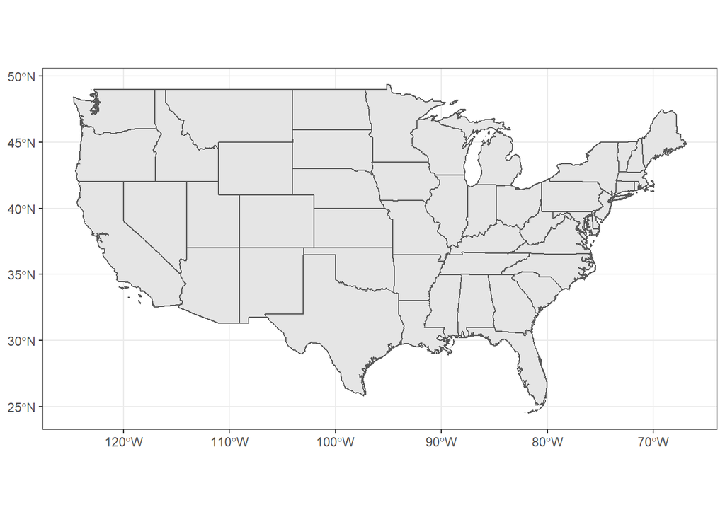

```r
US_states <- ne_states(country = "United States of America",
                       returnclass = "sf") %>%
  filter(name != "Alaska",
         name != "Hawaii")

US_map <- ggplot(US_states) +
  geom_sf() +
  theme_bw()

US_map
```

```r
#United States
USA_AEA <- "+proj=aea +lat_1=29.5 +lat_2=45.5 +lat_0=23 +lon_0=-96 +x_0=0 +y_0=0 +ellps=clrk66 +units=m +no_defs"
NY_state_plane <- "+proj=tmerc +lat_0=40 +lon_0=-78.58333333333333 +k=0.9999375 +x_0=350000 +y_0=0 +ellps=GRS80 +units=m +no_defs"
HI_AEA <- "+proj=aea +lat_1=8 +lat_2=18 +lat_0=13 +lon_0=-157 +x_0=0 +y_0=0 +ellps=GRS80 +datum=NAD83 +units=m +no_defs"
```

## Reprojecting based on USA Contiguous Albers Equal Area Conic

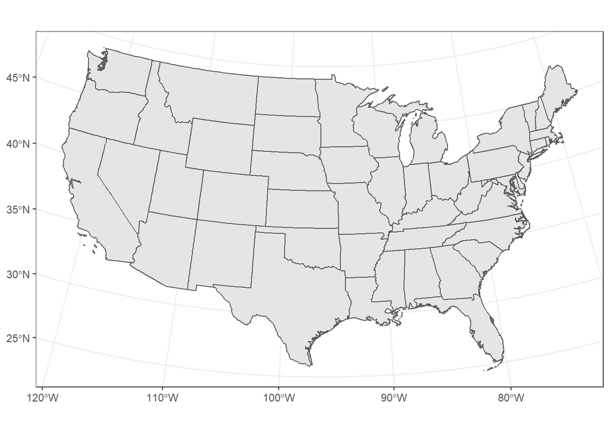

```r
ggplot(US_states) +
  geom_sf() +
  coord_sf(crs = USA_AEA) +
  theme_bw()
```

## Reprojecting based on New York West State Plane

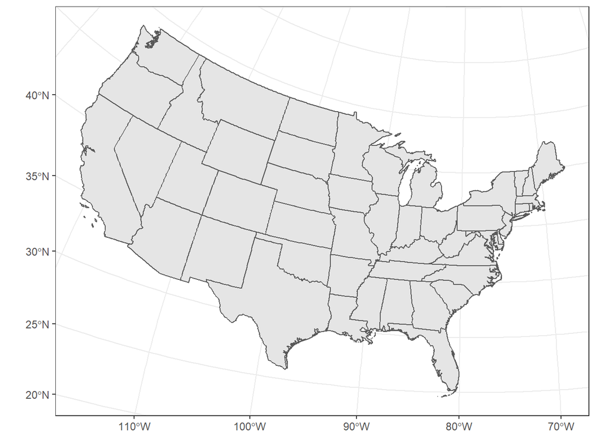

```r
ggplot(US_states) +
  geom_sf() +
  coord_sf(crs = NY_state_plane) +
  theme_bw()
```

## Reprojecting based on Hawaii Albers Equal Area Conic

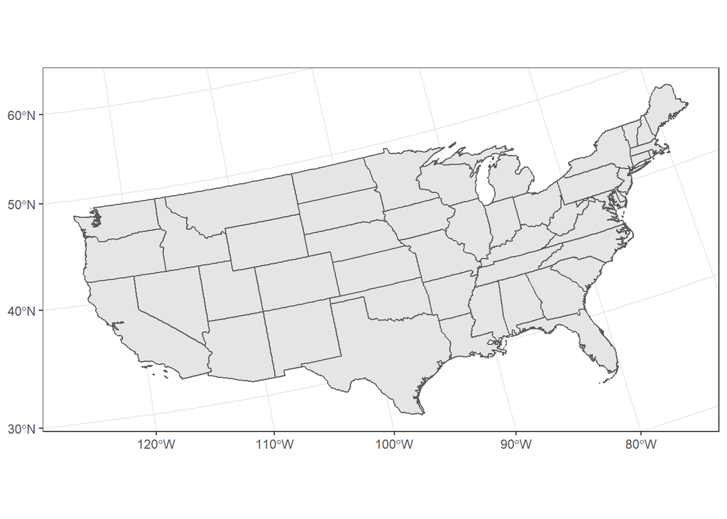

```r
ggplot(US_states) +
  geom_sf() +
  coord_sf(crs = HI_AEA) +
  theme_bw()
```

```r
states_transformed <- US_states %>%
  st_transform(crs = USA_AEA)
```

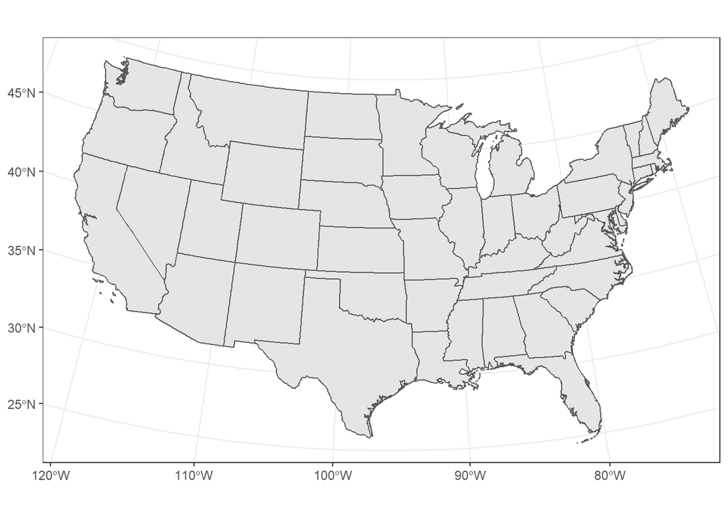

```r
ggplot(states_transformed) +
  geom_sf() +
  theme_bw()
```

```r
evictions_us <- read_csv("evictions_states.csv") %>%
  filter(year == 2016)

evictions_states <-states_transformed %>%
  left_join(evictions_us, by = "name") %>%
  select(name, postal, population, `eviction-rate`, `pct-af-am`)
```